# DM08

**演習では，他人のデバイスに触らない．自分のデバイスを，他人に触らせない．**

**新しいノートブックは作らない．**前回作業したノートブックは，Google Driveの「マイドライブ/Colab Notebooks」に保存されているはず．それを開いて再開する．

結果を提示しているのは，計算が正しいことを確認してもらうためである．結果の形式を完全に同じにする必要はない．

```python
import graphviz
import matplotlib.pyplot as plt
import numpy as np
import pandas as pd
import statsmodels.api as sm
from mlxtend.plotting import plot_decision_regions
from sklearn.compose import ColumnTransformer
from sklearn.datasets import fetch_openml
from sklearn.ensemble import RandomForestClassifier
from sklearn.metrics import ConfusionMatrixDisplay, confusion_matrix
from sklearn.model_selection import cross_val_score, GridSearchCV, LeaveOneOut
from sklearn.pipeline import Pipeline
from sklearn.preprocessing import LabelEncoder, OneHotEncoder, OrdinalEncoder
from sklearn.tree import DecisionTreeClassifier, export_graphviz, plot_tree
from xgboost import XGBClassifier

# K分割交差検証
def score_cv(model, X, y, k=5):
  return cross_val_score(model, X, y, cv=k).mean()

# 一つ抜き交差検証（LOOCV）
def score_loocv(model, X, y):
  return cross_val_score(model, X, y, cv=LeaveOneOut()).mean()
```

## 1 多値分類

### 1.1 アヤメのデータ（教科書9.1節）

https://archive.ics.uci.edu/dataset/53/iris

アヤメのデータを用意する方法はいろいろあるが，ここでは教科書に合わせてstatsmodelsのものを使う．

```python
data1 = sm.datasets.get_rdataset('iris', 'datasets').data
data1
```

入力変数の基本統計量を確認する．欠損は無い．

```python
data1.describe()
```

出力変数を確認する．50件ずつの3カテゴリ．

```python
data1.groupby('Species').size()
```

### 1.2 木による分類（教科書9.2節）

#### 1.2.1 分類木の概念

説明のために，四つの説明変数のうちの，二つ（Petal.LengthとPetal.Width）だけを使って，深さ（高さ）が最大2（根を入れて3）の分類木を作る（`max_depth=2`）．ここでは資料に掲載する結果と説明が同じになるように，乱数を固定する（`random_state=0`）．乱数の固定必須ではないし，これによって「再現性」が担保されるわけではない（たまたまの結果であることに変わりはない）．

```python
X = data1[['Petal.Length', 'Petal.Width']]
y = data1['Species']

model = DecisionTreeClassifier(max_depth=2, random_state=0)
model.fit(X, y);
```

分類木を描く．

```python
plot_tree(decision_tree=model,
          feature_names=X.columns,
          class_names=model.classes_,
          filled=True)
plt.tight_layout()
plt.show()
```

ノードの「gini」はジニ不純度 $G$ で，次のように定義される．
$$G:=1-\sum_{k=1}^np_k^2.$$

ここで，$p_k$ はクラス $k$ のインスタンスの割合である．

例2：「$\mathrm{gini}=0.168$」というノードのジニ不純度を計算する．
$$1-\left(\left(\dfrac{0}{54}\right)^2+\left(\dfrac{49}{54}\right)^2+\left(\dfrac{5}{54}\right)^2\right)=\dfrac{245}{1458}\simeq
0.168.$$

ジニ不純度を使って，分岐のコスト $J$ を次のように定義する．
$$J:=\dfrac{n_\mathrm{left}}{n}G_\mathrm{left}+\dfrac{n_\mathrm{right}}{n}G_\mathrm{right}$$

ここで，$n$ は対象ノードのインスタンス数，$n_\mathrm{left}$ は左の分岐先のノードのインスタンス数，$G_\mathrm{left}$ は左の分岐先のノードのジニ不純度である（$n_\mathrm{right}$，$G_\mathrm{right}$ も同様）．例として，ルートノードの分岐のコストを計算する．
$$\dfrac{50}{150}\times 0+\dfrac{100}{150}\times
0.5=\dfrac{1}{3}\simeq 0.333.$$

この分類木の決定境界を可視化する．（この説明用の図を描くために，入力変数を二つにした．）

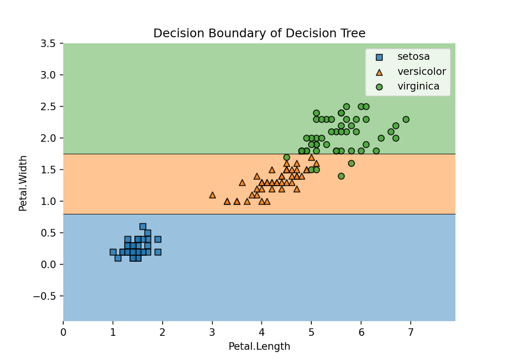

**課題** 二つの変数（Sepal.LengthとSepal.Width）だけを入力変数とする場合の分類木（`max_depth=2`）を作り，描け．

参考：決定境界を可視化する．

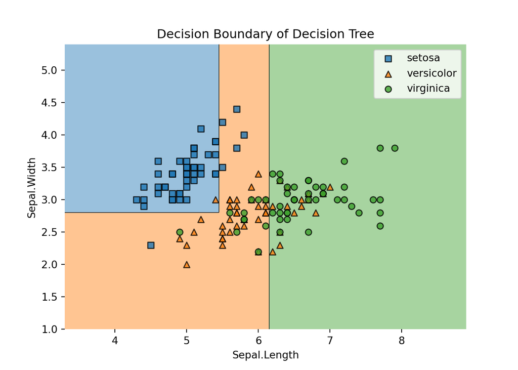

**課題** ルートノードの分岐のコストを求めて，それが最初の例（入力変数がPetal.LengthとPetal.Width）のルートノードの分岐コストより大きいことを確かめよ．

#### 1.2.2 分類木の実践

**課題** （四つの説明変数を使って）アヤメを分類する分類木（`max_depth=3`）を作り，描け．

**課題** 次のサンプルのSpeciesを予測せよ．

```
##    Sepal.Length  Sepal.Width  Petal.Length  Petal.Width
## 0           5.0          3.5           1.5          0.5
## 1           6.5          3.0           5.0          1.7
```

補足：各カテゴリに属する確率を求める．

```python
pd.DataFrame(model.predict_proba(test), columns=model.classes_)
```

```
##    setosa  versicolor  virginica
## 0     1.0    0.000000   0.000000
## 1     0.0    0.333333   0.666667
```

補足：変数の重要度を求めて，可視化する．

```python
tmp = pd.Series(model.feature_importances_, index=X.columns)
print(tmp)
tmp.sort_values().plot.barh();
```

### 1.3 正解率（教科書9.3節）

**課題** 訓練データにモデルを適用し，混同行列を作れ．

補足：見やすく表示する．

```python
ConfusionMatrixDisplay.from_estimator(model, X, y, cmap='Blues');
```

**課題** 正解率（訓練）を求めよ．

**課題** 正解率（LOOCV）を求めよ．

#### 1.3.1 性能向上の試み1：複雑な木

**課題** 木の深さが最大5の分類木を作り，描け．

**課題** 訓練データにモデルを適用し，混同行列を作れ．

**課題** 正解率（訓練）と正解率（LOOCV）を求めよ．

#### 1.3.2 性能向上の試み2：他の手法（教科書9.4節）

**課題** ランダムフォレストの正解率（訓練）と正解率（LOOCV）を求めよ．

**課題** ランダムフォレストでの変数の重要度を求めて，可視化せよ．

#### 1.3.3 性能向上の試み3：パラメータチューニング（教科書9.3.4項）♠

次のパラメータをチューニングし，最良モデルの正解率（LOOCV）を求める．

| 説明 | パラメータ | デフォルト値 | 探索範囲 |
| --- | --- | --- | --- |
| 木の高さの上限 | `max_depth` | 無制限 | 2以上6未満 |
| 終端ノードに属するサンプルのサイズの下限 | `min_samples_leaf` | 1 | 1以上8未満 |
| 分岐するノードに属するサンプルのサイズの下限 | `min_samples_split` | 2 | 2または20 |

```python
params = {
  'max_depth': range(2, 6),
  'min_samples_leaf': range(1, 8),
  'min_samples_split': (2, 20)}

search = GridSearchCV(
  DecisionTreeClassifier(random_state=0),
  param_grid=params,
  cv=LeaveOneOut(),
  n_jobs=-1) # 並列処理

search.fit(X, y);

print(search.best_params_) # 最良パラメータ（他にもあり得る）
```

```
## {'max_depth': 3, 'min_samples_leaf': 5, 'min_samples_split': 2}
```

```python
print(search.best_score_)
```

```
## 0.9733333333333334
```

変数の重要度は次のとおり．

```python
tmp = pd.Series(model.feature_importances_, index=X.columns)
print(tmp)
```

```
## Sepal.Length    0.090908
## Sepal.Width     0.024531
## Petal.Length    0.460445
## Petal.Width     0.424116
## dtype: float64
```

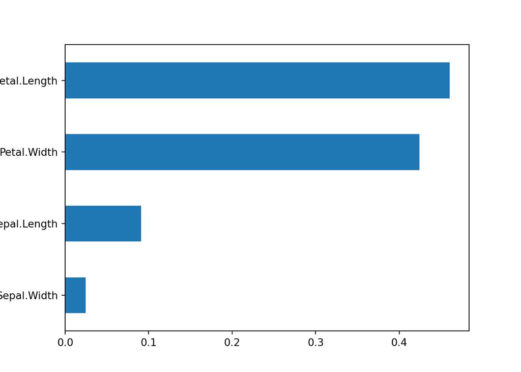

```python
tmp.sort_values().plot.barh();
```

#### 1.3.4 補足：分類木の貪欲さ

次のデータに対して，最大深さ2の分類木を作り，正解率（訓練）と正解率（LOOCV）を求めてみよう．

```python
data2 = pd.DataFrame([[1, 1, 0, 1],
                      [0, 0, 0, 2],
                      [1, 0, 1, 1],
                      [0, 1, 1, 2],
                      [1, 1, 1, 0],
                      [0, 0, 1, 1]], columns=['x0', 'x1', 'x2', 'y'])
X = data2.drop(columns=['y'])
y = data2['y']
```

次のように変数を減らした場合の，正解率（訓練）と正解率（LOOCV）を求めてみよう．

```python
X2 = X.drop(columns=['x0'])
```

### 1.4 実践

#### 1.4.1 ワインの品種

ワインの化学分析の結果からクラスを予測する問題を解く．参照：https://archive.ics.uci.edu/dataset/109/wine

```python
from sklearn.datasets import load_wine
data3 = load_wine()

X = data3.data
y = data3.target

tmp = pd.DataFrame(X, columns=data3.feature_names)
tmp['class'] = y
tmp.head()
```

出力変数（クラス）は次のとおり（これを信じてはいけない）．

| クラス | ワイン名 | サンプルサイズ | 特徴 |
| --- | --- | --- | --- |
| Class 0 | Barolo（バローロ） | 59 | - Nebbiolo（ネッビオーロ）種のブドウを使用 - 高級赤ワインとして知られる - ピエモンテ地方の代表的なワイン |
| Class 1 | Grignolino（グリニョリーノ） | 71 | - 同名のブドウ品種を使用 - 比較的軽めの赤ワイン - フルーティーな香りが特徴 |
| Class 2 | Barbera（バルベーラ） | 48 | - 同名のブドウ品種を使用 - 濃い色調と豊かな果実味が特徴 - ピエモンテ地方で最も広く栽培されている品種 |

入力変数は次のとおり（これを信じてはいけない）．

| 変数 | 日本語 | 説明 |
| --- | --- | --- |
| alcohol | アルコール度数 | ワイン中のアルコール含有量（%） |
| malic_acid | リンゴ酸 | ワインに含まれるリンゴ酸の量（g/L）。発酵過程や熟成度を示す指標 |
| ash | 灰分 | ワインを燃焼させた後に残る無機物質の総量（g/L） |
| alcalinity_of_ash | 灰分のアルカリ度 | 灰分のpH値を中和するために必要な酸の量 |
| magnesium | マグネシウム | ワイン中のマグネシウム含有量（mg/L） |
| total_phenols | 総フェノール量 | ワインに含まれる全フェノール化合物量。渋みや抗酸化性に関連 |
| flavanoids | フラバノイド | ワインに含まれるフラバノイド（フェノール類の一種）の量。色や渋みに影響 |
| nonflavanoid_phenols | 非フラバノイドフェノール | フラバノイド以外のフェノール化合物量 |
| proanthocyanins | プロアントシアニン | タンニンの一種で、熟成や渋みに関連する化合物量 |
| color_intensity | 色の濃さ | ワインの色の強さを示す指標 |
| hue | 色相 | ワインの色調（赤～茶色の度合い） |
| od280/od315_of_diluted_wines | 希釈ワインの吸光度比 | タンパク質量の指標。ワインの品質評価に使用 |
| proline | プロリン | アミノ酸の一種。ワインの品種や熟成度を示す指標（mg/L） |

**課題** 分類木とランダムフォレストの予測性能を，5分割交差検証で比較せよ．パラメータはデフォルトとすること．

#### 1.4.2 自動車の評価

```python
data4 = fetch_openml(name='car', version=1, as_frame=True).frame;
```

```python
data4.head()
```

変数の説明は次のとおり（これを信じてはいけない）．`class`が出力変数，他が入力変数である．

| **変数名** | **説明** | **値の例** |
| --- | --- | --- |
| `buying` | 車両購入価格 | `vhigh`（非常に高い）, `high`, `med`, `low` |
| `maint` | 車両維持費 | `vhigh`, `high`, `med`, `low` |
| `doors` | ドアの数 | `2`, `3`, `4`, `5more`（5枚以上） |
| `persons` | 車に乗れる人数 | `2`, `4`, `more`（それ以上） |
| `lug_boot` | トランクの容量 | `small`（小さい）, `med`, `big`（大きい） |
| `safety` | 安全性評価 | `low`, `med`, `high` |
| `class` | 車の総合評価（目的変数） | `unacc`（不適格）, `acc`（適格）, `good`（良好）, `vgood`（非常に良い） |

変数は全て質的変数である。とり得る値の範囲を確認する。

```python
for col in data4.columns:
  print(col)
  print(data4[col].unique())
  print()
```

class以外の列をX，classをyとする。ただし，XGBoostで学習できるように，classの値をunacc, acc, good, vgoodを0, 1, 2, 3に変換する。補足：OrdinalEncoderで変換することもできる。

```python
X = data4.drop(columns=['class'])
y = data4['class'].map({'unacc': 0, 'acc': 1, 'good': 2, 'vgood': 3})
y
```

**課題** 次のコードの実行結果を調べよ。

```python
model = DecisionTreeClassifier()
model.fit(X, y)
```

入力変数の値には順序があるから，`OneHotEncoder`より`OrdinalEncoder`が向いていると思われる。ここでは，両方試してみる。

補足：goodのインスタンスを誤ってvgoodと予測するのと，unaccのインスタンスを誤ってvgoodと予測するのでは深刻さが異なるのだが，ここでは正解率だけを見ることにする。

**課題** `OneHotEncoder(handle_unknown='ignore')`で質的変数を数値に変換して，`DecisionTreeClassifier(random_state=0)`を訓練し，5分割交差検証でで予測性能を見積もれ。

**課題** `RandomForestClassifier(random_state=0)`と`XGBClassifier(random_state=0)`の予測性能を見積もれ。

**課題** `OrdinalEncoder`で質的変数を数値に変換して，決定木を訓練し，5分割交差検証でで予測性能を見積もれ。ヒント：`OrdinalEncoder`の作り方を示す。

```python
categories = [
    ['low', 'med', 'high', 'vhigh'], # buying
    ['low', 'med', 'high', 'vhigh'], # maint
    ['2', '3', '4', '5more'],        # doors
    ['2', '4', 'more'],              # persons
    ['small', 'med', 'big'],         # lug_boot
    ['low', 'med', 'high']           # safety
]
oe = OrdinalEncoder(categories=categories)
```

**課題** `RandomForestClassifier(random_state=0)`と`XGBClassifier(random_state=0)`の予測性能を見積もれ。

補足：木の最大深さを3にした場合の分類木を描く．

```python
y = data4['class'] # 変数を数値に変換する前に戻す。

pipeline = Pipeline([
    ('oe', oe),
    ('model', DecisionTreeClassifier(max_depth=3, random_state=0))
])
pipeline.fit(X, y);

model = pipeline.named_steps['model']

plot_tree(decision_tree=model,
          feature_names=X.columns,
          class_names=model.classes_,
          filled=True)
plt.tight_layout()
plt.show()
```

**課題** （時間に余裕がある場合）生成AIで全てをやり直せ．